# Assignment 3, Task 2

Author

Gabriel Ingman

# Assignment 3, Task 2

```r
library(here)
library(tidyverse)
library(nlraa)
library(kableExtra)
library(patchwork)
library(purrr)
library(Metrics)
```

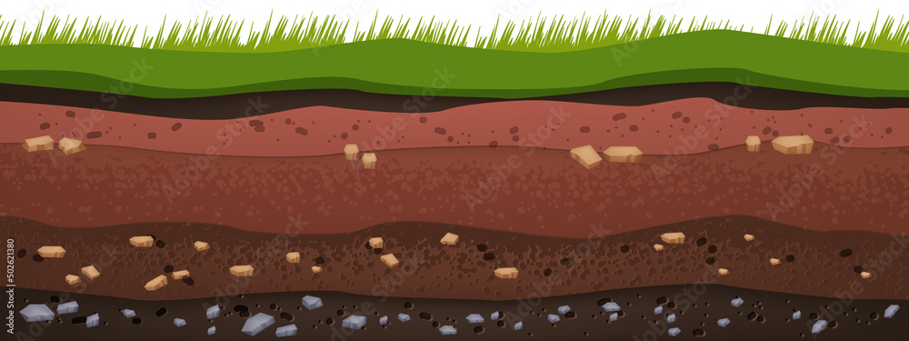

Soil

## Data Overview and Task Summary

Soil. It’s essential for agriculture. Crops grow in soil. This relationship- soil nurturing crops- is as predictable as it is simple. However, the actual mechanics of the relationship is complex, and the impacts of tending to crops (watering, spreading fertilizer) is not best represented by a linear relationship. There are a number of factors that affect crop growth, and the observation of those factors at play is best represented by a nonlinear model; a model that better tracks the irregular behavior of crops as they grow, so sayeth S.V. Archontoulis and F.E. Miguez.

In this task, I will run non-linear least square (NLS) analyses to recreate analyses performed in the paper by Archontoulis and Miguez, in order to make predictions regarding agricultural yield. In the interest of clarity, instead of a pseudocode header, I will provide short text explanations of each task as I complete it.

#### Data Citation

Archontoulis, S.V. and Miguez, F.E. (2015), Nonlinear Regression Models and Applications in Agricultural Research. Agronomy Journal, 107: 786-798. https://doi.org/10.2134/agronj2012.0506

```r
sm_raw <- sm %>%
  janitor::clean_names()
```

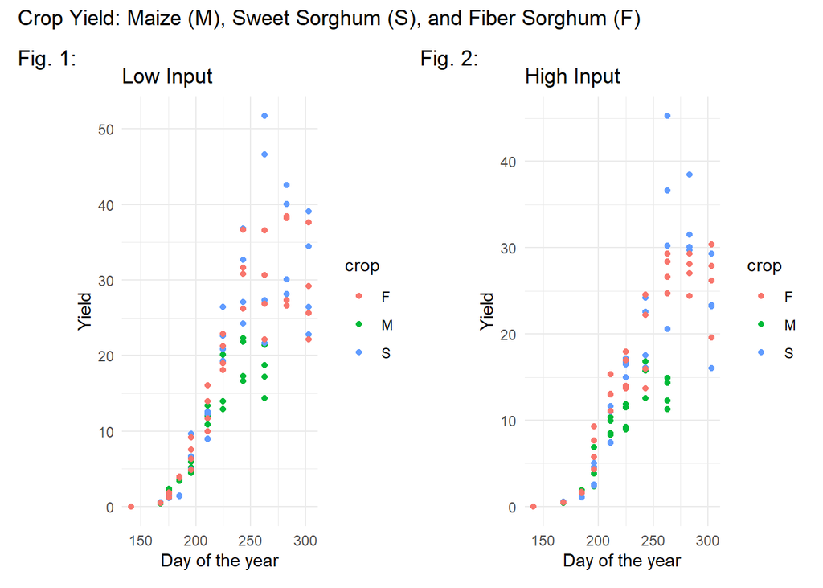

```r
high_in_df <- sm_raw %>%
  filter(input == 1)

low_in_df <- sm_raw %>%
  filter(input == 2)

high_in_plot <- ggplot(high_in_df, aes(x = doy, y = yield, color = crop)) +
  geom_point() +
  theme_minimal() +
  xlab('Day of the year') +
  ylab('Yield') +
  labs(title = 'High Input')

low_in_plot <- ggplot(low_in_df, aes(x = doy, y = yield, color = crop)) +
  geom_point() +
  theme_minimal() +
  xlab('Day of the year') +
  ylab('Yield') +
  labs(title = 'Low Input')


highlow_crop_plot <- low_in_plot + high_in_plot + plot_annotation(
  title = 'Crop Yield: Maize (M), Sweet Sorghum (S), and Fiber Sorghum (F)',
  tag_levels = '1',
  tag_prefix = 'Fig. ',
  tag_sep = '.',
  tag_suffix = ':',
)

highlow_crop_plot
```

## Beta Function

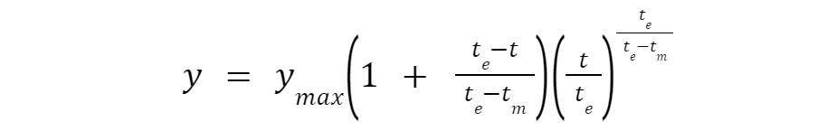

Beta formula

```r
beta <- function(ymax, t_e, t_m, doy){

  yield = ymax * (1 + (t_e - doy)/(t_e - t_m)) * (doy/t_e)^(t_e/(t_e - t_m))

  return(yield)}
```

```r
# Filter high-input df for sorghum species
high_sorghum <- high_in_df %>%
  filter(crop == c('S', 'F'))

# Run the NLS
high_sorghum_nls <- nls(yield ~ beta(ymax, t_e, t_m, doy),
                    data = high_sorghum,
                    start = list(ymax = 31, t_e = 280, t_m = 230),
                    trace = TRUE)
```

```
1421.328    (1.08e+00): par = (31 280 230)
1196.346    (8.75e-01): par = (33.62058 281.4791 253.8204)
737.9445    (1.92e-01): par = (33.24296 280.8876 246.8524)
711.6729    (5.21e-03): par = (34.17267 282.3351 248.4106)
711.6548    (5.32e-04): par = (34.18408 282.3364 248.3674)
711.6546    (9.34e-05): par = (34.18776 282.3372 248.3759)
711.6546    (1.64e-05): par = (34.18712 282.3371 248.3744)
711.6546    (2.86e-06): par = (34.18723 282.3371 248.3747)
```

```r
# Tabulate NLS results
broom::tidy(high_sorghum_nls) %>%
  janitor::clean_names(case = "title") %>%
  kable(digits = 60) %>%
  kable_paper('hover', full_width = F)
```

| Term | Estimate | Std Error | Statistic | P Value |
| --- | --- | --- | --- | --- |
| ymax | 34.18723 | 1.711874 | 19.97065 | 2.077631e-21 |
| t_e | 282.33712 | 1.591412 | 177.41299 | 8.034900e-56 |
| t_m | 248.37469 | 2.957384 | 83.98460 | 7.767665e-44 |

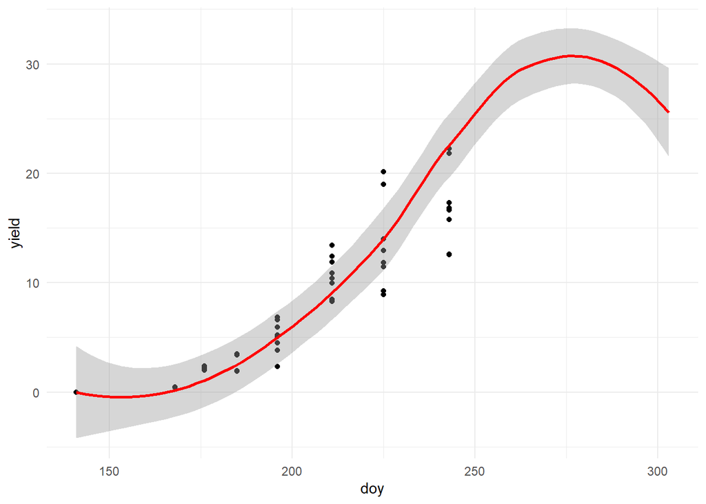

```r
# Make a maize data frame for plotting
maize_df <- sm_raw %>%
  filter(crop == 'M') %>%
  filter(doy < 263)

high_s_predict <- high_sorghum  %>%
  mutate(predict = predict(high_sorghum_nls, newdata ='.'))

ggplot(data = maize_df, aes(x = doy, y = yield)) +
  geom_point() +
  geom_smooth(data = high_s_predict, aes(x = doy, y = yield), color = 'red') +
  theme_minimal()
```

```r
# Define function to pass NLS along
total_nls_func <- function(yield){

  nls(yield ~ beta(ymax, t_e, t_m, doy),
      data = sm_raw,
      start = list(ymax = 31, t_e = 280, t_m = 230))
}

# Run the 24 NLS permutations
beta_all <- sm_raw %>%
  group_by(input, crop, block) %>%
  nest() %>%
  mutate(nls_model = map(data, ~total_nls_func(.x))) %>%
  mutate(predictions = map2(nls_model, data,
                            ~predict(.x, newdata = .y))) %>%
  mutate(RMSE = map2_dbl(predictions, data,
                         ~Metrics::rmse(.x, .y$yield))) %>%
  mutate(smooth = map(nls_model, # Smoothing
                      ~predict(.x, newdata = list(doy = seq(147, 306)))))
# 'smooth' is running the model between each doy point, creating smoothed line of best fit
```

```r
# Filtering separate data frames by species
beta_f <- beta_all %>%
  filter(crop == 'F') %>%
  group_by(crop) %>%
  slice_min(n=1, order_by = RMSE) # Extract row with minimum RMSE

beta_s <- beta_all %>%
  filter(crop == 'S') %>%
  group_by(crop) %>%
  slice_min(n=1, order_by = RMSE) # Extract row with minimum RMSE

beta_m <- beta_all %>%
  filter(crop == 'M') %>%
  group_by(crop) %>%
  slice_min(n=1, order_by = RMSE) # Extract row with minimum RMSE

# Combine 3 rows extracted above into new data frame
min_rmse <- full_join(beta_f, beta_s)
min_rmse <- full_join(min_rmse, beta_m)
min_rmse <- min_rmse %>%
  select(block, input, crop, RMSE)

# Tabulate minimum RMSE by species
min_rmse_tbl <- min_rmse %>%
  janitor::clean_names(case = "title") %>%
  kable(format = 'html', row.names = FALSE, digits = 15)  %>%
  kable_paper('hover', full_width = F)

min_rmse_tbl
```

| Block | Input | Crop | Rmse |
| --- | --- | --- | --- |
| 3 | 1 | F | 2.904144 |
| 4 | 1 | S | 3.351127 |
| 1 | 2 | M | 2.993202 |

## Recreating Figure 7

```r
# filter data and unnest smoothed values for plotting.Also adding a doy column

# Filter model predictions to block 1 with vector of days from 147 to 306
unnest_df <- beta_all %>%
  filter(block == 1) %>%
  tidyr::unnest(smooth) %>% # unnesting smooth values
  mutate(doy = seq(147, 306)) %>% # adding a doy column
  filter(!(doy > 263 & crop == 'M')) # Removing maize data that exceeds sorgum data


sm_filter <- sm_raw %>%
  filter(block == 1) %>%
  select(doy, yield)

unnest_sm_join <- left_join(unnest_df, sm_filter, by = join_by(doy))

predict_df <- beta_all %>%
 tidyr::unnest(smooth) %>%
  mutate(doy = seq(147, 306)) %>%
  filter(!(doy > 263 & crop == 'M')) %>%
  unnest(predictions)

predict_m <- predict_df %>%
  filter(crop == 'M')

predict_s <- predict_df %>%
  filter(crop == 'S')

predict_f <- predict_df %>%
  filter(crop == 'F')
```

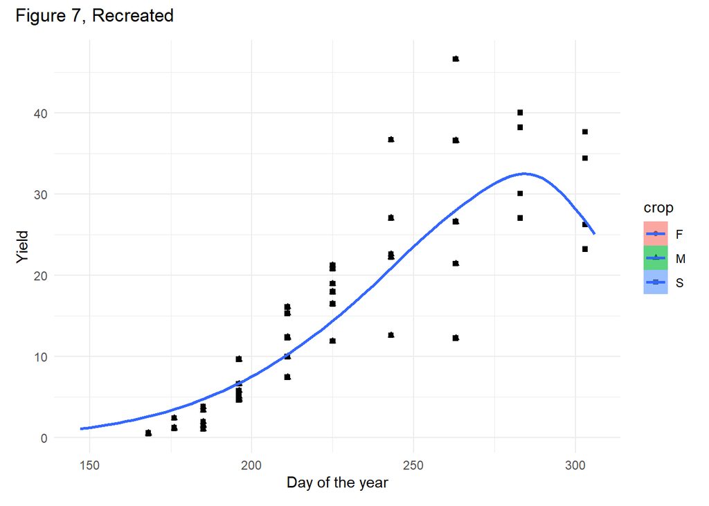

```r
fig7 <- ggplot(unnest_sm_join,
                    aes(x = doy, y = yield, shape = crop, fill = crop)) +
  geom_point() +
  geom_line(data = predict_m, aes(x = doy, y = smooth)) +
  geom_smooth(data = predict_f, aes(x = doy, y = smooth)) +
    geom_smooth(data = predict_s, aes(x = doy, y = smooth)) +
  labs(x = "Day of the year", y = "Yield") +
  theme_minimal()

fig7 + plot_annotation(
  title = 'Figure 7, Recreated'
)
```